# Project 1

Author

RodricK Mpofu

Statement of Integrity: “All work presented is my own, and I have followed all rules for collaboration. I have not discussed this project with anyone outside of students currently enrolled in this course, and I have listed any such students at the top of my project.”

Signed by: Rodrick Mpofu

```r
library(tidyverse)
library(readxl)
library(here)

majors_unclean <- read_xlsx(here("data/graduates_2022.xlsx"), sheet = 1, skip = 1)
majors_only <- majors_unclean |> filter(row_number() %in% 1:90 | `...1` == "GRADUATES") |>
  filter(!is.na(`...1`)) |>
  select(1, 2, starts_with("20")) |>
  select(c(1, 3:25))

majors_graduates <- majors_only |>
  pivot_longer(2:24, names_to = "year", values_to = "majors") |>
  mutate(year = parse_number(str_trunc(year, 7))) |>
  rename(major = "...1",
         n_majors = majors)

majors_df <- majors_graduates |> filter(major != "GRADUATES")
graduates_df <- majors_graduates |> filter(major == "GRADUATES") |>
  select(-major)

slumajors_df <- left_join(majors_df, graduates_df, by = "year") |>
  rename(n_majors = n_majors.x,
         n_graduates = n_majors.y)
slumajors_df
```

```
# A tibble: 1,219 × 4
   major         year n_majors n_graduates
   <chr>        <dbl>    <dbl>       <dbl>
 1 Biochemistry  2000        0         425
 2 Biochemistry  2001        0         400
 3 Biochemistry  2002        0         408
 4 Biochemistry  2003        2         452
 5 Biochemistry  2004        1         510
 6 Biochemistry  2005        2         434
 7 Biochemistry  2006        6         510
 8 Biochemistry  2007        5         500
 9 Biochemistry  2008        8         500
10 Biochemistry  2009        3         444
# … with 1,209 more rows
```

### Part 1

## Question 1

```r
slumajors_df <- slumajors_df |> mutate(major_prop = n_majors / n_graduates)
```

## Question 2

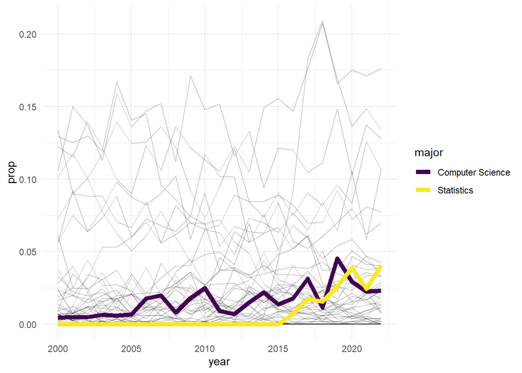

```r
## create a separate data frame wth Computer Science and Statistics filtered
label_df_colour <- slumajors_df |> filter((major == "Computer Science" |
                                             major == "Statistics"))

ggplot(slumajors_df, aes(x = year, y = major_prop, group = major)) +
  geom_line(alpha = 0.2) +
  labs(y = "prop") +
  scale_colour_viridis_d() +
  geom_line(data = label_df_colour, aes(colour = major), size = 2) +
  theme_minimal()
```

## Question 3

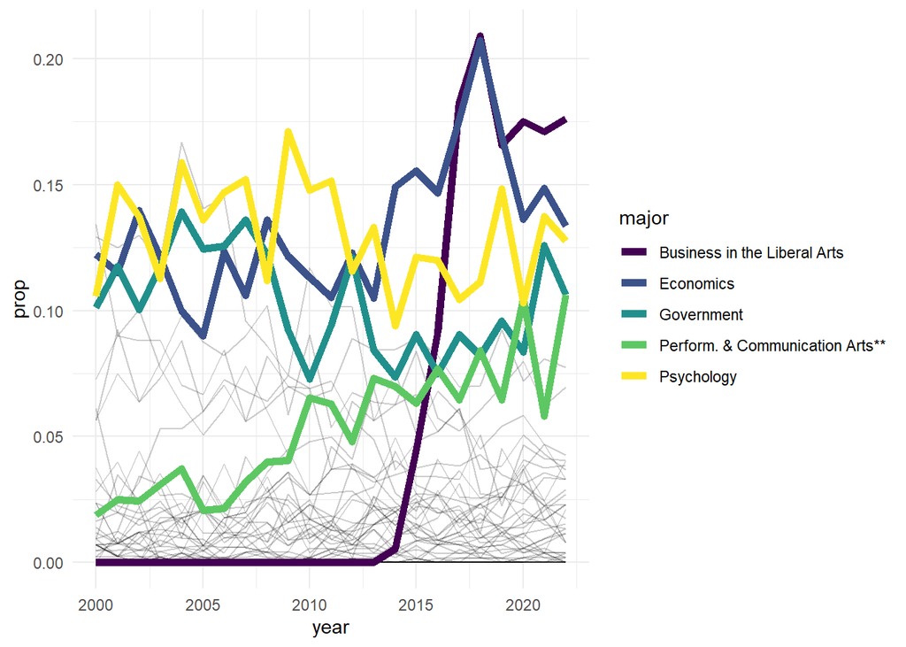

```r
## First create data set for most popular

pop5_df_colour <- slumajors_df |>
  filter((year == 2022)) |>
  arrange(desc(n_majors)) |>
  slice(1:5)

## filter out the 5 to make a line
pop5_line_df <- slumajors_df |>
  filter(major == "Business in the Liberal Arts" |
         major == "Economics" |
         major == "Psychology" |
         major == "Government" |
         major == "Perform. & Communication Arts**")

ggplot(slumajors_df, aes(x = year, y = major_prop, group = major)) +
  geom_line(alpha = 0.2) +
  labs(y = "prop") +
  scale_colour_viridis_d() +
  geom_line(data = pop5_line_df, aes(colour = major), size = 2) +
  theme_minimal()
```

## Question 4

Summary: Computer Science and Statics have gained a small proportion of popularity from 2000 to 2022. They still have a proportion of less than 0.05 of all graduates by the end of 2022. However, 4 of the most popular majors, Perfomance and Communication Arts, Economics, Government and Psychology remained very much popular throughout 2000 to 2022. Additionally, Business in the Liberal Arts gains or increases in popularity around 2014 until it becomes the most popular major in 2022.

## Question 5

```r
library(knitr)
yr_df<- slumajors_df |>
  filter(year >= 2018) |>
  group_by(major) |>
  summarise(avg_majors = mean(n_majors)) |>
  arrange(desc(avg_majors)) |>
  filter(avg_majors > 15) |>
  kable()

yr_df
```

| major | avg_majors |
| --- | --- |
| Business in the Liberal Arts | 94.8 |
| Economics | 84.2 |
| Psychology | 66.8 |
| Government | 52.4 |
| Perform. & Communication Arts** | 44.0 |
| Biology | 41.8 |
| English | 36.2 |
| Mathematics | 26.2 |
| History | 21.8 |
| Global Studies | 21.2 |
| Env. Studies (BA) (Combined) | 18.8 |
| Sociology | 18.0 |
| Environmental Studies | 17.4 |
| Statistics | 15.4 |

## Question 6

```r
## reprex example
toy_df <- tibble(group = c("A", "B", "A", "B"),
                 val = c(2, 5, 1, 9))
toy_df
```

```
# A tibble: 4 × 2
  group   val
  <chr> <dbl>
1 A         2
2 B         5
3 A         1
4 B         9
```

```r
toy_df |> group_by(group) |>
  summarise(diffs = diff(val))
```

```
# A tibble: 2 × 2
  group diffs
  <chr> <dbl>
1 A        -1
2 B         4
```

```r
avg_major_prop1 <- slumajors_df |>
  filter(year <= 2010 ) |>
  group_by(major) |>
  summarise(avg_major_prop = mean(major_prop))

avg_major_prop2 <- slumajors_df |>
  filter(year >= 2010 ) |>
  group_by(major) |>
  summarise(avg_major_prop = mean(major_prop))

avg_major_df <- bind_rows(avg_major_prop1, avg_major_prop2)

avg_major_df <- avg_major_df |> group_by(major) |>
  summarise(diffs = diff(avg_major_prop)) |>
  mutate(prop_change = case_when(diffs > 0.01 ~ "positive",
                                 diffs < - 0.01 ~ "negative",
                                 diffs > -0.01 & diffs < 0.01 ~ "little change"))
```

## Question 7

```r
positive_change_df <- avg_major_df |>
  filter(prop_change == "positive") |>
  arrange(desc(diffs)) |> kable()

positive_change_df
```

| major | diffs | prop_change |
| --- | --- | --- |
| Business in the Liberal Arts | 0.0939288 | positive |
| Perform. & Communication Arts** | 0.0400421 | positive |
| Economics | 0.0265174 | positive |
| Global Studies | 0.0225503 | positive |
| Conservation Biology | 0.0177039 | positive |
| Statistics | 0.0131035 | positive |
| Int’l Economics (Combined) | 0.0111861 | positive |
| Neuroscience | 0.0110556 | positive |

```r
negative_change_df <- avg_major_df |>
  filter(prop_change == "negative") |>
  arrange(diffs) |> kable()

negative_change_df
```

| major | diffs | prop_change |
| --- | --- | --- |
| English | -0.0459398 | negative |
| Art and Art History (Fine Arts) | -0.0323159 | negative |
| History | -0.0246847 | negative |
| Sociology | -0.0232922 | negative |
| Government | -0.0214948 | negative |
| Psychology | -0.0149047 | negative |

## Question 8

Summary: Business in the liberal Arts had the highest average graduating majors with an average of 94.8 graduates per year since 2018. Most majors popularity proportion had a little change. Business in the Liberal Arts had the biggest change, a difference in proportion of 0.094. English had the largest negative change in proportion suggesting that more people opted for other majors such as Business in the Liberal Arts.

### Part 2

1. I am interested in the trend of the popularity of mathematics as major from the year 2000 till 2022. Is there a positive trend or negative trend? And also where did this popularity peak and where was it as its lowest.

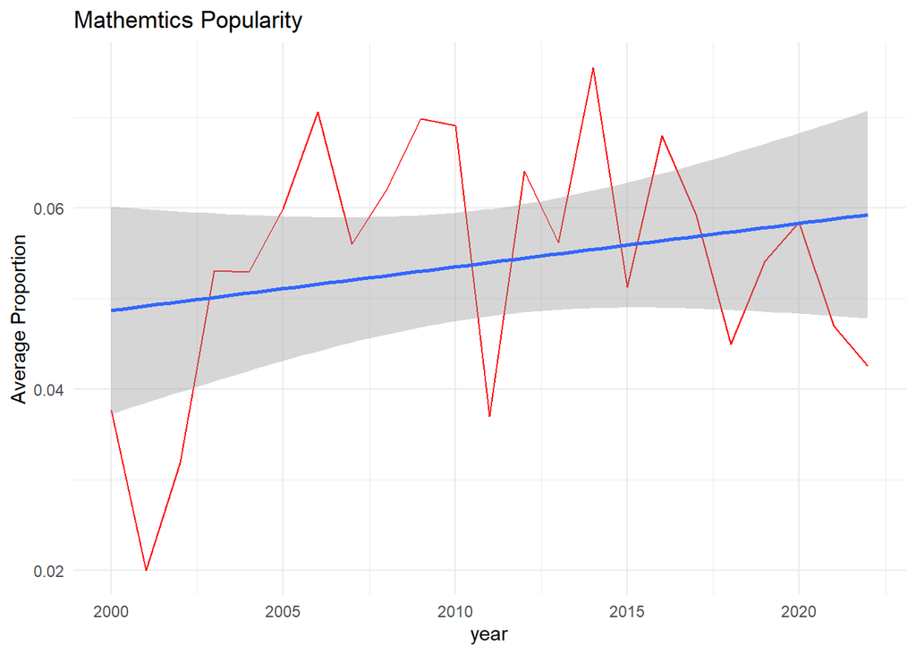

```r
avg1 <- slumajors_df |> filter(major == "Mathematics") |>group_by(major, year) |>
  summarise(avg_major_prop = mean(major_prop))

ggplot(avg1, aes(x= year, y = avg_major_prop)) +
  geom_line(colour = "red") + labs(y = "Average Proportion", title = "Mathemtics Popularity") +
  geom_smooth(method=lm) + theme_minimal()
```

3. From the graph it shows that mathematics did have a positive trend from the year 2000 till 2022. This is shown by the upward sloping blue trend-line. The peak was in 2014 and lowest in 2001.